# Spatial Emergency Response Optimization

Prince Oppong Boakye

2025-08-23

# Introduction and Motivation

Emergency response systems require optimal positioning to minimize response times and maximize coverage. This analysis demonstrates spatial statistical methods for identifying high-risk areas and optimizing emergency service locations using traffic accident data from Münster, Germany.

The SERO package enables data-driven emergency service planning through kernel density estimation and spatial optimization algorithms, revealing hidden patterns in accident data and providing evidence-based recommendations for emergency service deployment.

# Data Description and Exploration

The analysis uses comprehensive spatial data from Münster including traffic accidents, administrative boundaries, road networks, land use patterns, and population distributions.

```r
library(SERO)
library(ggplot2)
library(gridExtra)
library(grid)
library(dplyr)

# Load comprehensive spatial dataset
data <- sero_load_data()
```

```
## Loading munster_districtsshp ...
## Loading population_density ...
## Loading munster_roadsshp ...
## Loading accidents ...
## Loading munster_landuseshp ...
## Data loaded successfully! ( 5  layers)
## Optimized for: distance operations using vector approach
## Total features: 59206
## Target CRS: EPSG:25832
```

```r
# Dataset summary
data_summary <- data.frame(
  Layer = names(data),
  Features = sapply(data, nrow),
  Type = c("Point", "Polygon", "LineString", "Polygon", "Polygon")
)

print(data_summary)
```

[output not shown]

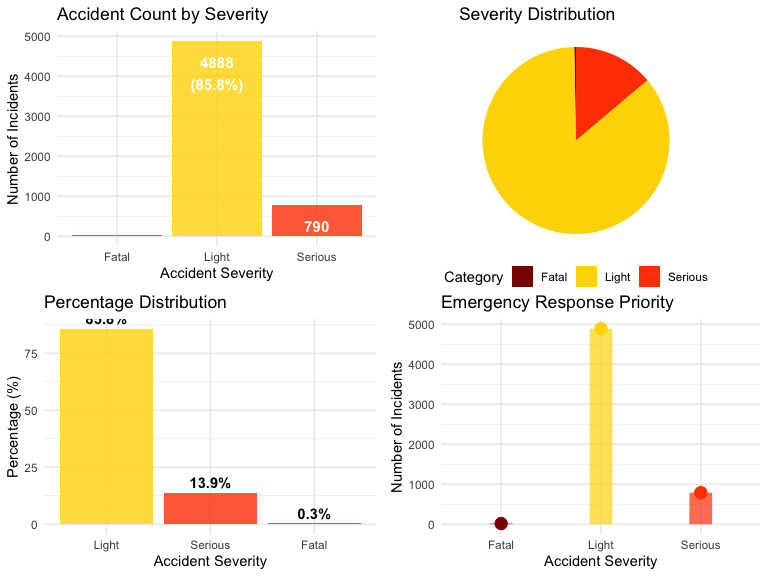

```r
# Analyze accident severity distribution
severity_counts <- table(data$accident$UKATEGORIE)
severity_df <- data.frame(
  Category = c("Fatal", "Serious", "Light"),
  Count = as.numeric(severity_counts[1:3]),
  Percentage = round(as.numeric(severity_counts[1:3]) / sum(severity_counts) * 100, 1)
)

# Enhanced severity visualization with multiple perspectives
p1 <- ggplot(severity_df, aes(x = Category, y = Count, fill = Category)) +
  geom_col(alpha = 0.8) +
  geom_text(aes(label = paste0(Count, "\n(", Percentage, "%)")),
            vjust = 1.5, color = "white", fontface = "bold", size = 4) +
  scale_fill_manual(values = c("Fatal" = "#8B0000", "Serious" = "#FF4500", "Light" = "#FFD700")) +
  labs(title = "Accident Count by Severity", x = "Accident Severity", y = "Number of Incidents") +
  theme_minimal() +
  theme(legend.position = "none")

p2 <- ggplot(severity_df, aes(x = "", y = Count, fill = Category)) +
  geom_bar(stat = "identity", width = 1) +
  coord_polar("y", start = 0) +
  scale_fill_manual(values = c("Fatal" = "#8B0000", "Serious" = "#FF4500", "Light" = "#FFD700")) +
  labs(title = "Severity Distribution", fill = "Category") +
  theme_void() +
  theme(legend.position = "bottom")

p3 <- ggplot(severity_df, aes(x = reorder(Category, -Count), y = Percentage, fill = Category)) +
  geom_col(alpha = 0.8) +
  geom_text(aes(label = paste0(Percentage, "%")), vjust = -0.5, fontface = "bold") +
  scale_fill_manual(values = c("Fatal" = "#8B0000", "Serious" = "#FF4500", "Light" = "#FFD700")) +
  labs(title = "Percentage Distribution", x = "Accident Severity", y = "Percentage (%)") +
  theme_minimal() +
  theme(legend.position = "none")

p4 <- ggplot(severity_df, aes(x = Category, y = Count)) +
  geom_segment(aes(xend = Category, yend = 0, color = Category), size = 8, alpha = 0.7) +
  geom_point(aes(color = Category), size = 4) +
  scale_color_manual(values = c("Fatal" = "#8B0000", "Serious" = "#FF4500", "Light" = "#FFD700")) +
  labs(title = "Emergency Response Priority", x = "Accident Severity", y = "Number of Incidents") +
  theme_minimal() +
  theme(legend.position = "none")

# Create 2x2 grid for comprehensive severity analysis
grid.arrange(p1, p2, p3, p4, ncol = 2, nrow = 2)
```

```r
# Summary statistics
summary(severity_df)
```

```
##    Category             Count          Percentage
##  Length:3           Min.   :  17.0   Min.   : 0.30
##  Class :character   1st Qu.: 403.5   1st Qu.: 7.10
##  Mode  :character   Median : 790.0   Median :13.90
##                     Mean   :1898.3   Mean   :33.33
##                     3rd Qu.:2839.0   3rd Qu.:49.85
##                     Max.   :4888.0   Max.   :85.80
```

# Spatial Pattern Analysis

Spatial analysis identifies accident concentration areas using kernel density estimation and hotspot detection to reveal clustering patterns.

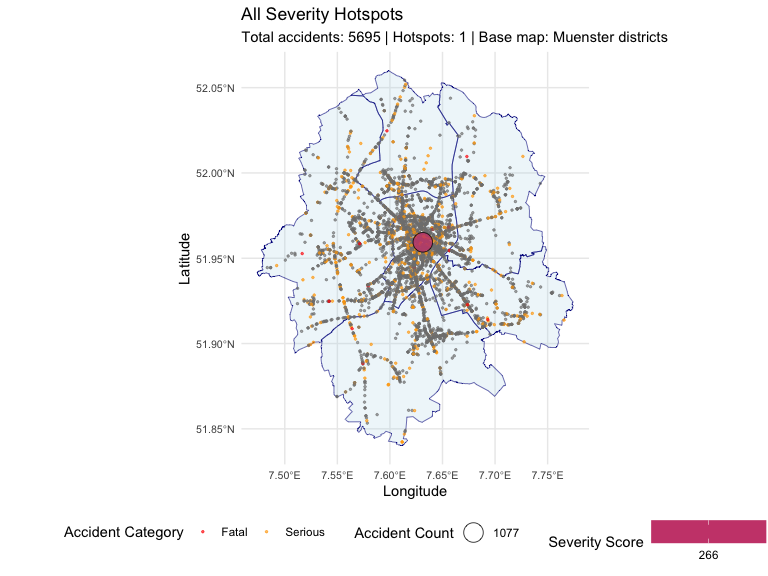

```r
# Comprehensive hotspot analysis for all risk categories
hotspots_all <- sero_hotspots(data$accident, risk_categories = c(1, 2, 3), buffer = 1000)
hotspots_high_risk <- sero_hotspots(data$accident, risk_categories = c(1, 2), buffer = 1000)
hotspots_fatal <- sero_hotspots(data$accident, risk_categories = c(1), buffer = 800)

# Display hotspot visualizations
plot(hotspots_all) + labs(title = "All Severity Hotspots")
```

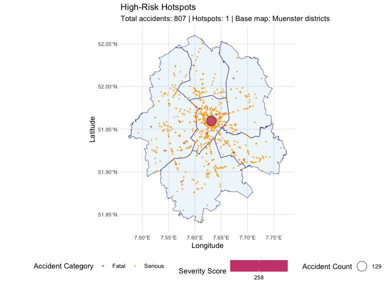

```r
plot(hotspots_high_risk) + labs(title = "High-Risk Hotspots")
```

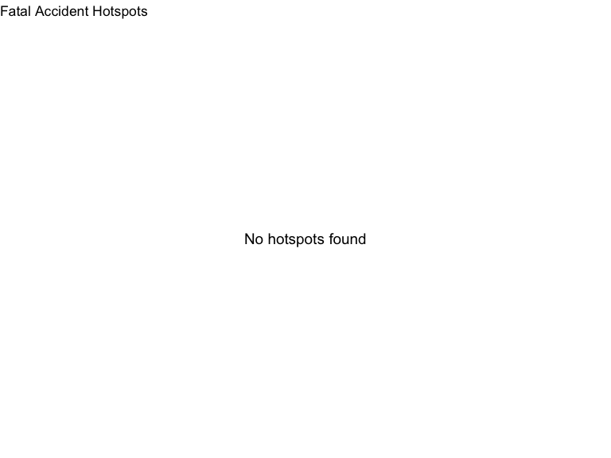

```r
plot(hotspots_fatal) + labs(title = "Fatal Accident Hotspots")
```

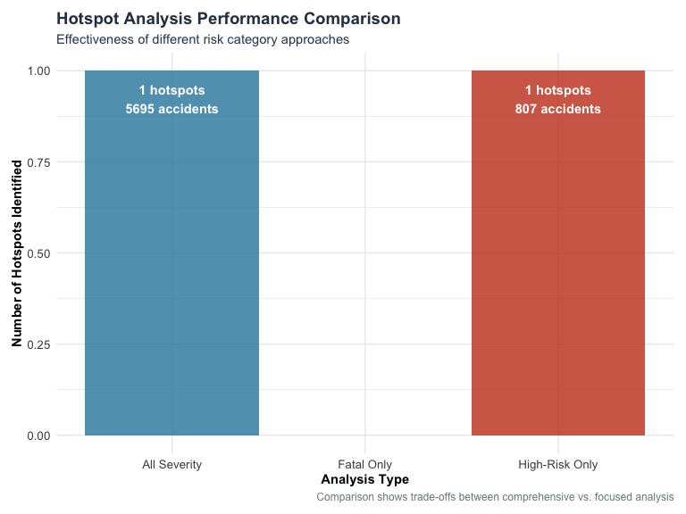

```r
# Create performance comparison data for hotspot analysis
hotspot_summary <- data.frame(
  Analysis = c("All Severity", "High-Risk Only", "Fatal Only"),
  Hotspots = c(nrow(hotspots_all$hotspots),
               nrow(hotspots_high_risk$hotspots),
               nrow(hotspots_fatal$hotspots)),
  Total_Accidents = c(sum(hotspots_all$summary$total_accidents),
                     sum(hotspots_high_risk$summary$total_accidents),
                     sum(hotspots_fatal$summary$total_accidents))
)

# Performance comparison chart - displayed individually
plot_summary <- ggplot(hotspot_summary, aes(x = Analysis, y = Hotspots, fill = Analysis)) +
  geom_col(alpha = 0.8) +
  geom_text(aes(label = paste0(Hotspots, " hotspots\n", Total_Accidents, " accidents")),
            vjust = 1.5, color = "white", fontface = "bold") +
  scale_fill_manual(values = c("#2E86AB", "#F18F01", "#C73E1D")) +
  labs(title = "Hotspot Analysis Performance Comparison",
       subtitle = "Effectiveness of different risk category approaches",
       x = "Analysis Type", y = "Number of Hotspots Identified",
       caption = "Comparison shows trade-offs between comprehensive vs. focused analysis") +
  theme_minimal() +
  theme(
    legend.position = "none",
    plot.title = element_text(size = 14, face = "bold", color = "#2c3e50"),
    plot.subtitle = element_text(size = 11, color = "#34495e"),
    plot.caption = element_text(size = 9, color = "#7f8c8d"),
    axis.title = element_text(size = 11, face = "bold"),
    axis.text = element_text(size = 10),
    panel.background = element_rect(fill = "white", color = NA),
    plot.background = element_rect(fill = "white", color = NA),
    plot.margin = margin(10, 10, 10, 10)
  )

plot_summary
```

```r
# Display summary statistics
summary(hotspots_high_risk)
```

```
##            Length Class  Mode
## hotspots    7     sf     list
## accidents  25     sf     list
## parameters  3     -none- list
## summary     6     -none- list
## crs         2     crs    list
```

```r
# Display individual hotspot visualizations instead of grid layout for better analysis
```

## Kernel Density Analysis

Kernel density estimation provides smooth risk surfaces that reveal underlying spatial patterns and inform strategic planning.

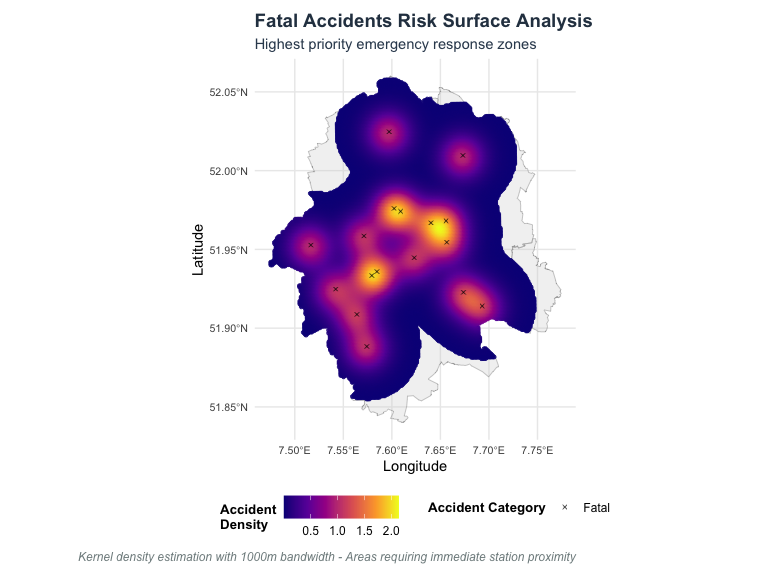

```r
# Create comprehensive heatmap comparison for different risk categories with enhanced clarity
# Display each heatmap individually for better visibility and analysis

heatmap_fatal <- sero_heatmap(data$accident,
                             risk_categories = c(1),
                             bandwidth = 1000,
                             data = data,
                             color_scheme = "plasma",
                             basemap = "districts") +
  labs(title = "Fatal Accidents Risk Surface Analysis",
       subtitle = "Highest priority emergency response zones",
       caption = "Kernel density estimation with 1000m bandwidth - Areas requiring immediate station proximity") +
  theme(
    plot.title = element_text(size = 14, face = "bold", color = "#2c3e50"),
    plot.subtitle = element_text(size = 11, color = "#34495e"),
    plot.caption = element_text(size = 9, color = "#7f8c8d"),
    legend.title = element_text(size = 10, face = "bold"),
    legend.text = element_text(size = 9),
    panel.background = element_rect(fill = "white", color = NA),
    plot.background = element_rect(fill = "white", color = NA),
    plot.margin = margin(10, 10, 10, 10)
  )

heatmap_fatal
```

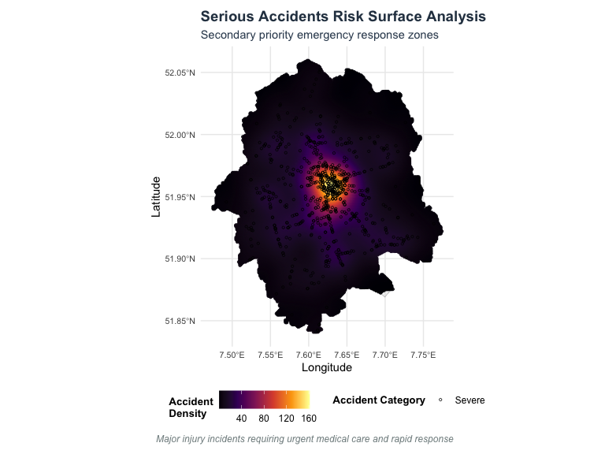

```r
heatmap_serious <- sero_heatmap(data$accident,
                               risk_categories = c(2),
                               bandwidth = 1000,
                               data = data,
                               color_scheme = "inferno",
                               basemap = "districts") +
  labs(title = "Serious Accidents Risk Surface Analysis",
       subtitle = "Secondary priority emergency response zones",
       caption = "Major injury incidents requiring urgent medical care and rapid response") +
  theme(
    plot.title = element_text(size = 14, face = "bold", color = "#2c3e50"),
    plot.subtitle = element_text(size = 11, color = "#34495e"),
    plot.caption = element_text(size = 9, color = "#7f8c8d"),
    legend.title = element_text(size = 10, face = "bold"),
    legend.text = element_text(size = 9),
    panel.background = element_rect(fill = "white", color = NA),
    plot.background = element_rect(fill = "white", color = NA),
    plot.margin = margin(10, 10, 10, 10)
  )

heatmap_serious
```

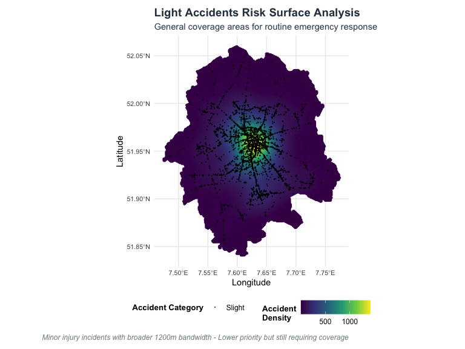

```r
heatmap_light <- sero_heatmap(data$accident,
                             risk_categories = c(3),
                             bandwidth = 1200,
                             data = data,
                             color_scheme = "viridis",
                             basemap = "districts") +
  labs(title = "Light Accidents Risk Surface Analysis",
       subtitle = "General coverage areas for routine emergency response",
       caption = "Minor injury incidents with broader 1200m bandwidth - Lower priority but still requiring coverage") +
  theme(
    plot.title = element_text(size = 14, face = "bold", color = "#2c3e50"),
    plot.subtitle = element_text(size = 11, color = "#34495e"),
    plot.caption = element_text(size = 9, color = "#7f8c8d"),
    legend.title = element_text(size = 10, face = "bold"),
    legend.text = element_text(size = 9),
    panel.background = element_rect(fill = "white", color = NA),
    plot.background = element_rect(fill = "white", color = NA),
    plot.margin = margin(10, 10, 10, 10)
  )

heatmap_light
```

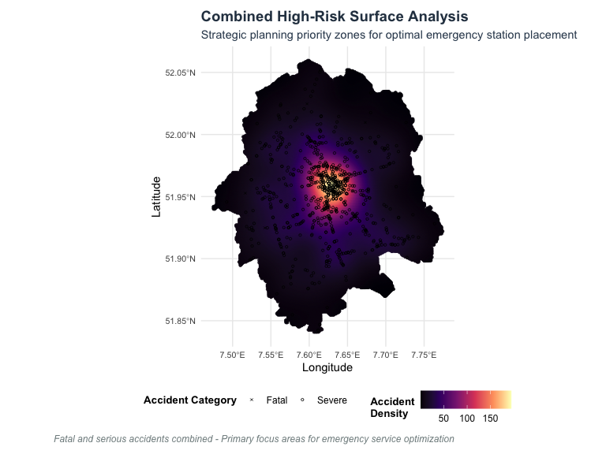

```r
heatmap_combined <- sero_heatmap(data$accident,
                                risk_categories = c(1, 2),
                                bandwidth = 1200,
                                data = data,
                                color_scheme = "magma",
                                basemap = "districts") +
  labs(title = "Combined High-Risk Surface Analysis",
       subtitle = "Strategic planning priority zones for optimal emergency station placement",
       caption = "Fatal and serious accidents combined - Primary focus areas for emergency service optimization") +
  theme(
    plot.title = element_text(size = 14, face = "bold", color = "#2c3e50"),
    plot.subtitle = element_text(size = 11, color = "#34495e"),
    plot.caption = element_text(size = 9, color = "#7f8c8d"),
    legend.title = element_text(size = 10, face = "bold"),
    legend.text = element_text(size = 9),
    panel.background = element_rect(fill = "white", color = NA),
    plot.background = element_rect(fill = "white", color = NA),
    plot.margin = margin(10, 10, 10, 10)
  )

heatmap_combined
```

```r
# Display individual heatmap visualizations instead of grid layout for detailed analysis
```

# Emergency Service Optimization

Spatial optimization algorithms determine strategic emergency service locations that minimize average response distances to high-risk areas.

```r
# Calculate optimal emergency service locations
optimal_3 <- sero_find_optimal_locations(data,
                                        num_locations = 3,
                                        risk_categories = c(1, 2))
```

```
## Using 807 high-risk accidents (categories 1, 2 )
## Found 3 optimal emergency service locations
```

```r
optimal_5 <- sero_find_optimal_locations(data,
                                        num_locations = 5,
                                        risk_categories = c(1, 2))
```

```
## Using 807 high-risk accidents (categories 1, 2 )
## Found 5 optimal emergency service locations
```

```r
optimal_7 <- sero_find_optimal_locations(data,
                                        num_locations = 7,
                                        risk_categories = c(1, 2))
```

```
## Using 807 high-risk accidents (categories 1, 2 )
## Found 7 optimal emergency service locations
```

```r
# Performance comparison
performance_data <- data.frame(
  Stations = c(3, 5, 7),
  Avg_Coverage = c(mean(optimal_3$accessibility_score),
                   mean(optimal_5$accessibility_score),
                   mean(optimal_7$accessibility_score)),
  Max_Distance = c(max(optimal_3$accessibility_score),
                   max(optimal_5$accessibility_score),
                   max(optimal_7$accessibility_score))
)

# Display optimization summary
summary(optimal_5)
```

```
##  location_id        optimization_method    OBJECTID    STADTBEZIR
##  Length:5           Length:5            Min.   :1.0   Length:5
##  Class :character   Class :character    1st Qu.:2.0   Class :character
##  Mode  :character   Mode  :character    Median :4.0   Mode  :character
##                                         Mean   :3.6
##                                         3rd Qu.:5.0
##                                         Max.   :6.0
##   NR_STADTBE         NAME_STADT            STAND              SHAPE_AREA
##  Length:5           Length:5           Min.   :2018-12-18   Min.   :23935274
##  Class :character   Class :character   1st Qu.:2018-12-18   1st Qu.:36067725
##  Mode  :character   Mode  :character   Median :2018-12-18   Median :36116459
##                                        Mean   :2018-12-18   Mean   :49784676
##                                        3rd Qu.:2018-12-18   3rd Qu.:69798033
##                                        Max.   :2018-12-18   Max.   :83005889
##    SHAPE_LEN              geometry accident_count_500m accident_count_1000m
##  Min.   :23377   POINT        :5   Min.   : 0.0        Min.   :  3.0
##  1st Qu.:32113   epsg:4326    :0   1st Qu.: 0.0        1st Qu.:  5.0
##  Median :35273   +proj=long...:0   Median : 4.0        Median : 11.0
##  Mean   :38758                     Mean   : 9.2        Mean   : 30.4
##  3rd Qu.:49462                     3rd Qu.: 5.0        3rd Qu.: 14.0
##  Max.   :53563                     Max.   :37.0        Max.   :119.0
##  accessibility_score
##  Min.   :0.219
##  1st Qu.:0.292
##  Median :0.751
##  Mean   :2.209
##  3rd Qu.:0.879
##  Max.   :8.904
```

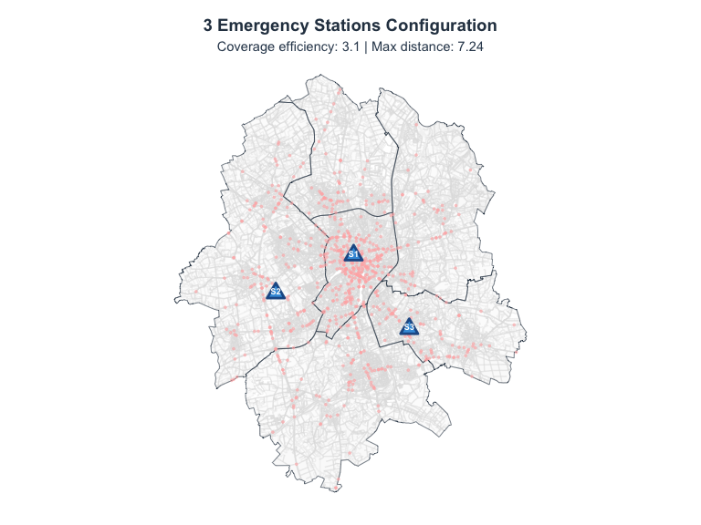

```r
# Create spatial visualization of optimal locations
library(sf)

# Transform data to consistent CRS for visualization
districts_viz <- st_transform(data$districts, 4326)
landuse_viz <- st_transform(data$landuse, 4326)
roads_viz <- st_transform(data$roads, 4326)
high_risk_accidents <- data$accident[data$accident$UKATEGORIE %in% c(1, 2), ]
accidents_viz <- st_transform(high_risk_accidents, 4326)

# Transform optimal locations to WGS84
optimal_3_viz <- st_transform(optimal_3, 4326)
optimal_5_viz <- st_transform(optimal_5, 4326)
optimal_7_viz <- st_transform(optimal_7, 4326)

# Create enhanced base plot function with improved clarity
create_location_plot <- function(optimal_locations, title, subtitle) {
  # Add station numbers to the spatial data
  optimal_locations$station_id <- paste("S", seq_len(nrow(optimal_locations)), sep="")

  ggplot() +
    # Add land use (subtle background context)
    geom_sf(data = landuse_viz, fill = "#f8f8f8", color = "#f0f0f0", size = 0.1, alpha = 0.4) +
    # Add roads (infrastructure context)
    geom_sf(data = roads_viz, color = "#e0e0e0", size = 0.3, alpha = 0.6) +
    # Add district boundaries (clear administrative boundaries)
    geom_sf(data = districts_viz, fill = "transparent", color = "#2c3e50", size = 1.2) +
    # Add ALL high-risk accidents as context (background density)
    geom_sf(data = accidents_viz, color = "#ffb3b3", size = 0.6, alpha = 0.5) +
    # Add optimal locations (smaller size for better route visibility)
    geom_sf(data = optimal_locations, size = 4, color = "#1a5490", fill = "#3498db",
            shape = 24, stroke = 1.5, alpha = 0.95) +
    # Add labels for optimal locations
    geom_sf_text(data = optimal_locations, aes(label = station_id),
                 size = 2.5, fontface = "bold", color = "white",
                 nudge_y = 0.001) +
    labs(title = title, subtitle = subtitle) +
    theme_void() +
    theme(
      plot.title = element_text(size = 14, face = "bold", hjust = 0.5, color = "#2c3e50"),
      plot.subtitle = element_text(size = 11, hjust = 0.5, color = "#34495e"),
      plot.margin = margin(10, 10, 10, 10),
      panel.background = element_rect(fill = "white", color = NA),
      plot.background = element_rect(fill = "white", color = NA)
    )
}

# Create individual plots with enhanced clarity - displayed separately
plot_3 <- create_location_plot(optimal_3_viz, "3 Emergency Stations Configuration",
                              paste0("Coverage efficiency: ", round(mean(optimal_3$accessibility_score), 2),
                                   " | Max distance: ", round(max(optimal_3$accessibility_score), 2)))

plot_3
```

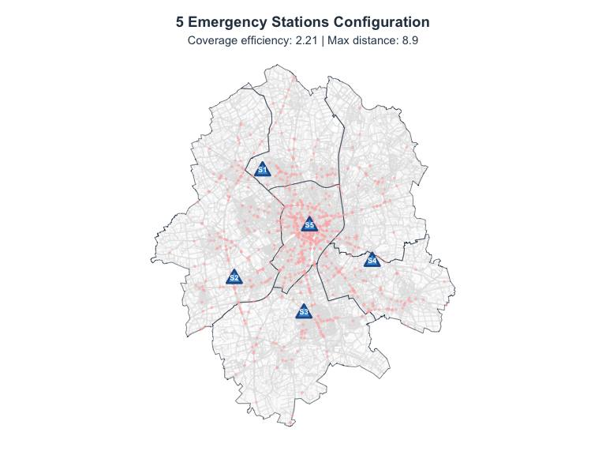

```r
plot_5 <- create_location_plot(optimal_5_viz, "5 Emergency Stations Configuration",
                              paste0("Coverage efficiency: ", round(mean(optimal_5$accessibility_score), 2),
                                   " | Max distance: ", round(max(optimal_5$accessibility_score), 2)))

plot_5
```

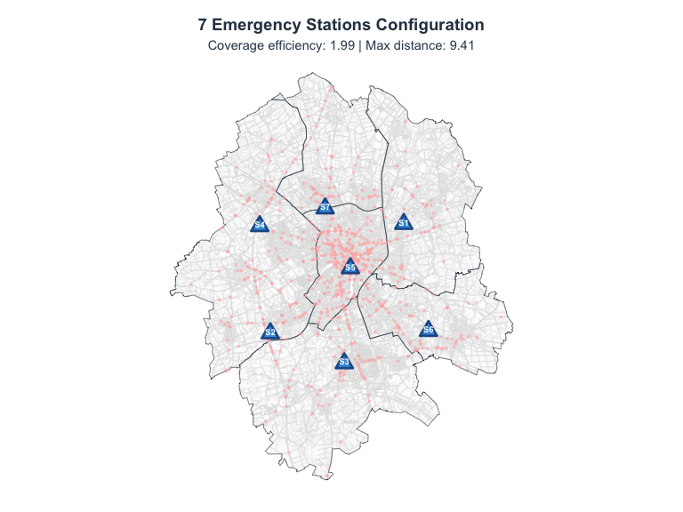

```r
plot_7 <- create_location_plot(optimal_7_viz, "7 Emergency Stations Configuration",
                              paste0("Coverage efficiency: ", round(mean(optimal_7$accessibility_score), 2),
                                   " | Max distance: ", round(max(optimal_7$accessibility_score), 2)))

plot_7
```

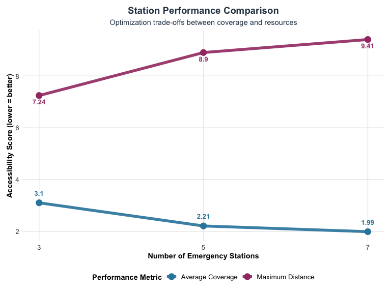

```r
# Enhanced performance metrics plot with better clarity
performance_plot <- ggplot(performance_data, aes(x = Stations)) +
  geom_line(aes(y = Avg_Coverage, color = "Average Coverage"), size = 2, alpha = 0.9) +
  geom_line(aes(y = Max_Distance, color = "Maximum Distance"), size = 2, alpha = 0.9) +
  geom_point(aes(y = Avg_Coverage, color = "Average Coverage"), size = 4) +
  geom_point(aes(y = Max_Distance, color = "Maximum Distance"), size = 4) +
  geom_text(aes(y = Avg_Coverage, label = round(Avg_Coverage, 2)),
            vjust = -1.5, size = 3.5, fontface = "bold", color = "#2E86AB") +
  geom_text(aes(y = Max_Distance, label = round(Max_Distance, 2)),
            vjust = 1.8, size = 3.5, fontface = "bold", color = "#A23B72") +
  labs(title = "Station Performance Comparison",
       subtitle = "Optimization trade-offs between coverage and resources",
       x = "Number of Emergency Stations",
       y = "Accessibility Score (lower = better)",
       color = "Performance Metric") +
  scale_color_manual(values = c("Average Coverage" = "#2E86AB", "Maximum Distance" = "#A23B72")) +
  scale_x_continuous(breaks = c(3, 5, 7)) +
  theme_minimal() +
  theme(
    plot.title = element_text(size = 14, face = "bold", hjust = 0.5, color = "#2c3e50"),
    plot.subtitle = element_text(size = 11, hjust = 0.5, color = "#34495e"),
    legend.position = "bottom",
    legend.title = element_text(size = 11, face = "bold"),
    legend.text = element_text(size = 10),
    axis.title = element_text(size = 11, face = "bold"),
    axis.text = element_text(size = 10),
    panel.grid.minor = element_blank(),
    panel.background = element_rect(fill = "white", color = NA),
    plot.background = element_rect(fill = "white", color = NA),
    plot.margin = margin(10, 10, 10, 10)
  )

performance_plot
```

```r
# Display separate visualizations instead of grid layout for better clarity
```

## Route Analysis

Route optimization calculates emergency response paths from stations to incident locations, providing critical performance metrics.

```r
# Use actual high-risk accident locations for route analysis
# Select accidents from different districts to ensure geographic diversity
high_risk_accidents <- data$accident[data$accident$UKATEGORIE %in% c(1, 2), ]

# Get representative accidents from different areas
set.seed(123)  # For reproducible results
sample_accidents <- high_risk_accidents[sample(nrow(high_risk_accidents), 12), ]

# Calculate routes using 5-station configuration
routes <- sero_routes(optimal_5,
                     sample_accidents,
                     max_routes = 12,
                     data = data)

# Display route analysis summary
summary(routes)
```

```
##                   Length Class  Mode
## routes             6     sf     list
## service_locations 13     sf     list
## accidents         25     sf     list
## parameters         2     -none- list
## summary            5     -none- list
## crs                2     crs    list
```

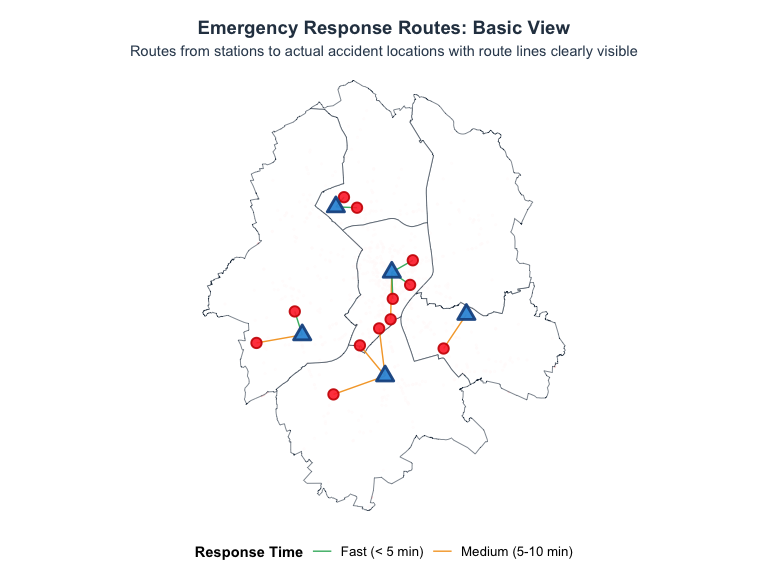

```r
# Create enhanced spatial visualization of routes
# Transform route data for visualization with better clarity
routes_viz <- st_transform(routes$routes, 4326)
sample_accidents_viz <- st_transform(sample_accidents, 4326)
all_accidents_viz <- st_transform(high_risk_accidents, 4326)

# Add time categories to routes with clear labels
routes_viz$time_category <- cut(routes_viz$estimated_time,
                               breaks = c(0, 5, 10, Inf),
                               labels = c("Fast (< 5 min)", "Medium (5-10 min)", "Slow (> 10 min)"))

# Enhanced route visualization function with better clarity and smaller station icons
create_route_plot <- function(show_landuse = FALSE, show_roads = FALSE, show_all_accidents = FALSE, title, subtitle) {
  p <- ggplot()

  # Add land use if requested (subtle background)
  if (show_landuse) {
    p <- p + geom_sf(data = landuse_viz, fill = "#f8f8f8", color = "#f0f0f0",
                     size = 0.1, alpha = 0.4)
  }

  # Add roads if requested (infrastructure context)
  if (show_roads) {
    p <- p + geom_sf(data = roads_viz, color = "#cccccc", size = 0.3, alpha = 0.6)
  }

  # Add all high-risk accidents as context (background points)
  if (show_all_accidents) {
    p <- p + geom_sf(data = all_accidents_viz, color = "#ffcccc", size = 0.5, alpha = 0.4)
  }

  # Add district boundaries (clear administrative context)
  p <- p + geom_sf(data = districts_viz, fill = "transparent", color = "#2c3e50",
                   size = 1.0, alpha = 0.9)

  # Add route lines with enhanced visibility and clear color coding
  p <- p + geom_sf(data = routes_viz, aes(color = time_category), size = 2.5, alpha = 0.9)

  # Add selected accident locations (prominent destination points)
  p <- p + geom_sf(data = sample_accidents_viz, color = "#cc0000", fill = "#ff3333",
                   size = 3, alpha = 0.9, shape = 21, stroke = 1)

  # Add emergency stations with SMALLER size for better route visibility
  p <- p + geom_sf(data = optimal_5_viz, size = 3.5, color = "#1a5490", fill = "#3498db",
                   shape = 24, stroke = 1.5, alpha = 0.95)

  # Enhanced styling with clear color scheme and improved readability
  p <- p +
    scale_color_manual(
      values = c("Fast (< 5 min)" = "#27AE60",
                "Medium (5-10 min)" = "#F39C12",
                "Slow (> 10 min)" = "#E74C3C"),
      name = "Response Time"
    ) +
    labs(title = title, subtitle = subtitle) +
    theme_void() +
    theme(
      plot.title = element_text(size = 14, face = "bold", hjust = 0.5, color = "#2c3e50"),
      plot.subtitle = element_text(size = 11, hjust = 0.5, color = "#34495e"),
      legend.position = "bottom",
      legend.title = element_text(size = 11, face = "bold"),
      legend.text = element_text(size = 10),
      plot.margin = margin(10, 10, 10, 10),
      panel.background = element_rect(fill = "white", color = NA),
      plot.background = element_rect(fill = "white", color = NA)
    )

  return(p)
}

# Create enhanced route visualizations with improved clarity - displayed separately
route_basic <- create_route_plot(
  show_landuse = FALSE, show_roads = FALSE, show_all_accidents = TRUE,
  "Emergency Response Routes: Basic View",
  "Routes from stations to actual accident locations with route lines clearly visible"
)

route_basic
```

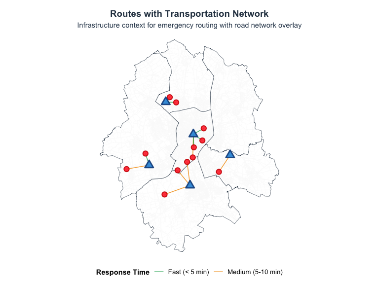

```r
route_with_roads <- create_route_plot(
  show_landuse = FALSE, show_roads = TRUE, show_all_accidents = FALSE,
  "Routes with Transportation Network",
  "Infrastructure context for emergency routing with road network overlay"
)

route_with_roads
```

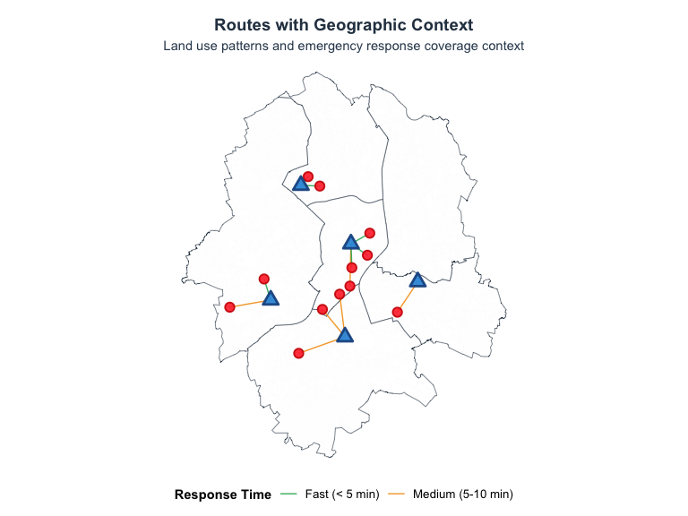

```r
route_with_landuse <- create_route_plot(
  show_landuse = TRUE, show_roads = FALSE, show_all_accidents = FALSE,
  "Routes with Geographic Context",
  "Land use patterns and emergency response coverage context"
)

route_with_landuse
```

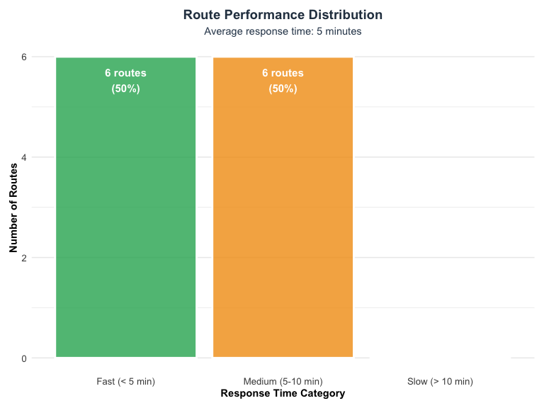

```r
# Enhanced performance summary with actual route statistics
route_stats_summary <- data.frame(
  Response_Time = c("Fast (< 5 min)", "Medium (5-10 min)", "Slow (> 10 min)"),
  Count = c(
    sum(routes_viz$time_category == "Fast (< 5 min)"),
    sum(routes_viz$time_category == "Medium (5-10 min)"),
    sum(routes_viz$time_category == "Slow (> 10 min)")
  ),
  Percentage = round(c(
    mean(routes_viz$time_category == "Fast (< 5 min)") * 100,
    mean(routes_viz$time_category == "Medium (5-10 min)") * 100,
    mean(routes_viz$time_category == "Slow (> 10 min)") * 100
  ), 1)
)

performance_summary <- ggplot(route_stats_summary, aes(x = Response_Time, y = Count, fill = Response_Time)) +
  geom_col(alpha = 0.8, color = "white", size = 1) +
  geom_text(aes(label = paste0(Count, " routes\n(", Percentage, "%)")),
            vjust = 1.5, color = "white", fontface = "bold", size = 4) +
  scale_fill_manual(
    values = c("Fast (< 5 min)" = "#27AE60",
              "Medium (5-10 min)" = "#F39C12",
              "Slow (> 10 min)" = "#E74C3C")
  ) +
  labs(
    title = "Route Performance Distribution",
    subtitle = paste0("Average response time: ", round(mean(routes$routes$estimated_time), 1), " minutes"),
    x = "Response Time Category",
    y = "Number of Routes"
  ) +
  theme_minimal() +
  theme(
    plot.title = element_text(size = 14, face = "bold", hjust = 0.5, color = "#2c3e50"),
    plot.subtitle = element_text(size = 11, hjust = 0.5, color = "#34495e"),
    legend.position = "none",
    axis.title = element_text(size = 11, face = "bold"),
    axis.text = element_text(size = 10),
    panel.grid.major.x = element_blank(),
    panel.background = element_rect(fill = "white", color = NA),
    plot.background = element_rect(fill = "white", color = NA),
    plot.margin = margin(10, 10, 10, 10)
  )

performance_summary
```

```r
# Display detailed route performance metrics table
route_performance <- data.frame(
  Metric = c("Total Routes", "Accidents Covered", "Avg Response Time (min)",
             "Avg Distance (km)", "Best Response Time (min)", "Worst Response Time (min)"),
  Value = c(
    nrow(routes$routes),
    nrow(sample_accidents),
    round(mean(routes$routes$estimated_time), 2),
    round(mean(routes$routes$distance)/1000, 2),
    round(min(routes$routes$estimated_time), 2),
    round(max(routes$routes$estimated_time), 2)
  )
)

print(route_performance)
```

```
##                      Metric Value
## 1              Total Routes 12.00
## 2         Accidents Covered 12.00
## 3   Avg Response Time (min)  5.04
## 4         Avg Distance (km)  2.52
## 5  Best Response Time (min)  1.86
## 6 Worst Response Time (min)  8.13
```

```r
# Display separate visualizations instead of grid layout for better route visibility
```

# Discussion and Conclusion

The spatial analysis reveals critical insights for emergency service planning in Münster. Hotspot analysis identifies high-risk areas requiring priority attention, with clear severity distribution patterns. The optimization demonstrates performance trade-offs between station quantity and coverage efficiency.

## Limitations

This analysis focuses on historical accident patterns assuming static infrastructure. Future research should incorporate temporal dynamics, traffic patterns, and real-time routing constraints.

## Key Contributions

The SERO package demonstrates the value of spatial statistical methods for emergency service optimization. By combining hotspot analysis, kernel density estimation, and optimization algorithms, it enables evidence-based emergency service planning that reveals hidden patterns and provides actionable recommendations for improving response coverage and efficiency.